# Task 1: Palmetto Binary Logistic Regression

Claire Meuter

2023-02-12

```r
knitr::opts_chunk$set(echo = TRUE, warning = FALSE, message = FALSE)
library(tidyverse)
library(GGally)
library(reshape2)
library(ggplot2)
library(here)
library(AICcmodavg)
library(tidymodels)
library(kableExtra)
library(modelsummary)
library(patchwork)
```

### Section A: Introduction

This code wrangles, explores and compares two species of Florida Palmetto, *Serenoa repens* and *Sabal etonia*. Within this code, two binary logistic regression models for predicting palmetto species were created and compared. The more accurate model, Model 1, was evaluated for success of predicting palmetto species.

Data for this code is sourced from the Archbold Biological Station in south-central Florida.

**Citation:** Abrahamson, W.G. 2019. Survival, growth and biomass estimates of two dominant palmetto species of south-central Florida from 1981 - 2017, ongoing at 5-year intervals ver 1. Environmental Data Initiative. https://doi.org/10.6073/pasta/f2f96ec76fbbd4b9db431c79a770c4d5

### Section B: Data Wrangling and Data Visualization

```r
# Read in the data
palmetto <- read_csv(here("palmetto.csv")) %>%
  select(species, height, length, width, green_lvs) %>% #keeping only the columns that I need
  mutate(species = case_when(species == 1 ~ "Serenoa repens", #renaming number labels to species names
                             species == 2 ~ "Sabal etonia"),
         species = factor(species)) %>% #factoring my species
  drop_na() #dropping any NAs

#Intial data exploration with ggpairs from the GGally package
# ggpairs(data = palmetto, aes(color = species))
```

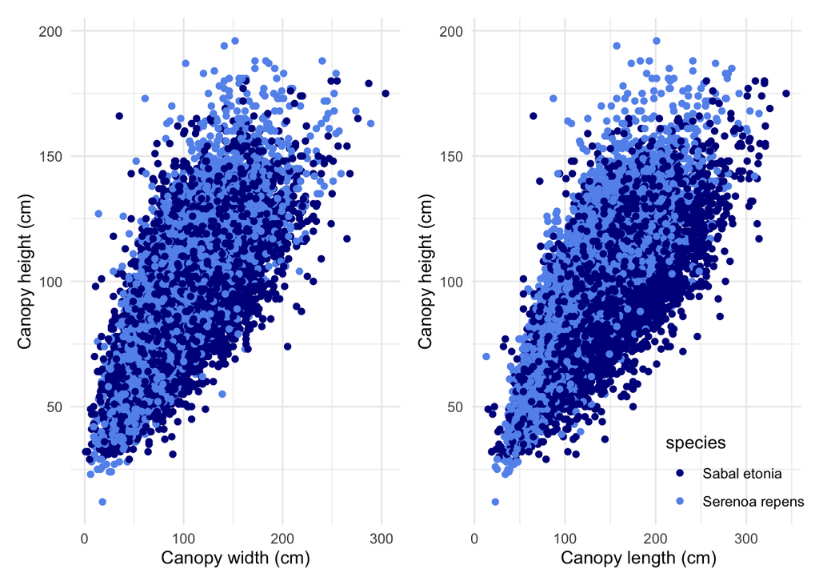

```r
# visualize differences in height, canopy length, canopy width, and green leaves
#graph of width by height
width <- ggplot(data = palmetto) +
  geom_point(aes(x = width, y = height, color = species)) +
  labs(x = "Canopy width (cm)",
       y = "Canopy height (cm)") +
  scale_color_manual(values = c("darkblue","cornflowerblue")) +
  theme_minimal() + theme(legend.position = "none") #getting rid of legend for this graph


#graph of width by length
length <- ggplot(data = palmetto) +
  geom_point(aes(x = length, y = height, color = species)) +
  labs(x = " Canopy length (cm)",
       y = "Canopy height (cm)") +
  scale_color_manual(values = c("darkblue","cornflowerblue")) +
  theme_minimal() +
   # set legend up
  theme(
    legend.position = c(0.8, 0.1))


 # combining graphs into one figure
width + length
```

```r
# histogram of green leaves by species
green_lvs <- ggplot(data = palmetto, aes(x = green_lvs)) +
  #boxes for s.etonia
  geom_histogram(data = subset(palmetto, species == 'Sabal etonia'),
                 aes(fill = species),
                 binwidth = 1, boundary = -0.5, color = "black", alpha = 0.5) +
  #boxes for s.repens
  geom_histogram(data = subset(palmetto, species == 'Serenoa repens'),
                 aes(fill = species),
                 binwidth = 1, boundary = -0.5,
                 color = 'black', alpha = 0.3) +
  #set colors and legend values
  scale_fill_manual(name = 'Species',
                    values = c('darkblue', 'cornflowerblue'),
                    labels = c('S. etonia', 'S. repens')) +
  #force origin to (0,0) and x-axis labels through 17
  scale_x_continuous(expand = c(0, 0), limits = c(0, 18), breaks=1:17) +
  scale_y_continuous(expand = c(0, 0), limits = c(0, 2100)) +
  #axis labels
  labs(x = 'Number of green leaves',
       y = 'Count') +
  #set theme
  theme_minimal()
```

Figure 1: Two scatterplots comparing the relationship between canopy height and width (left) and canopy height and length (right), between two palmetto species, *Sabel entonia* (dark blue) and *Serenoa repens* (light blue). A visual exploration of canopy height and width shows little variation between the *S. entonia* and *S. repens* species. A visual exploration of canopy height and length shows a slight variation between *S. entonia* and *S. repens* species, with *S. entonia* showing a slightly longer canopy length compared to *S. repens.*

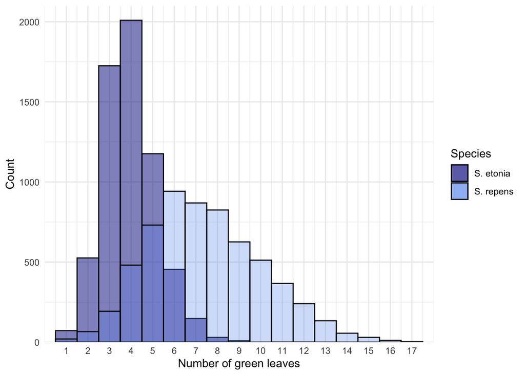

```r
green_lvs
```

Figure 2: A histogram displaying the number of green leaves on *S. etonia* and *S. repens.* *S. etonia* observations are colored dark blue, and *S. repens* observations are colored light blue. Where the count of green leaves between species overlaps, the graph is a combination blue color.

#### Takeaway from data exploration:

Based on Figures 1 and 2, it seems likely that number of green leaves and canopy length will be the most important in determining if a plant is *S. etonia* or *S. repens.* Canopy width shows little variation between the two species, but it could still be a useful model parameter, which will be explored in the next section.

### Section C: Comparison of two binary logistic regression models to determine the probability of a plant being either Serenoa repens or Sabal etonia

```r
#First, I create a formula for model 1 with variables plant height, canopy length, canopy width and green leaves
f1 <- species ~ height + length + width + green_lvs
#Next, a formula for model 2 with variables plant height, canopy width and green leaves
f2 <- species ~ height + width + green_lvs

#Now I can run both of my models:
mdl1 <- glm(f1, palmetto, family = "binomial")
mdl2 <- glm(f2, palmetto, family = "binomial")

# Get a tidy version w/ broom
mdl1_tidy <- tidy(mdl1)
mdl2_tidy <- tidy(mdl1)

#using AIC for initial exploration
AIC <- aictab(list(mdl1, mdl2),
              modnames = c("Model 1", "Model 2"))
#initally, model 1 is looking like the better fit, but now I'll do 10-fold cross validation to confirm
```

```r
## Tidymodels crossfold validation
set.seed(444) ##setting seed for reproducibility purposes


### use a workflow that bundles the logistic model and a formula
 palmetto_model <- logistic_reg() %>%
  set_engine('glm')

tidy_folds <- vfold_cv(palmetto, v = 10, repeats = 5) # With v = 10, I set the number of folds to ten, and repeat it 5 times

#Now I run model 1
palm_tidy_wf1 <- workflow() %>%
  add_model(palmetto_model) %>%
  add_formula(f1)

palm_tidy_cv_f1 <- palm_tidy_wf1 %>%
  fit_resamples(tidy_folds)

### use functions from the tune package to extract useful metrics
metrics_md1 <- collect_metrics(palm_tidy_cv_f1)

### Repeating tidymodel method for model 2

palm_tidy_wf2 <- workflow() %>%
  add_model(palmetto_model) %>%
  add_formula(f2)

palm_tidy_cv_f2 <- palm_tidy_wf2 %>%
  fit_resamples(tidy_folds)

### use functions from the tune package to extract useful metrics
metrics_md2 <- collect_metrics(palm_tidy_cv_f2)


# Format tables

## model 1
metrics_md1 %>%
  kable(caption = '**Table 1.** Cross validation metrics for Model 1.',
        col.names = c('Metric', 'Estimator', 'Mean',
                      'n', 'Standard error', 'Configuration')) %>%
  kable_styling(full_width = FALSE,
                bootstrap_options = "hover",
                position = "left")
```

**Table 1.** Cross validation metrics for Model 1.

| Metric | Estimator | Mean | n | Standard error | Configuration |
| --- | --- | --- | --- | --- | --- |
| accuracy | binary | 0.9168015 | 50 | 0.0011359 | Preprocessor1_Model1 |
| roc_auc | binary | 0.9725303 | 50 | 0.0005240 | Preprocessor1_Model1 |

```r
## model 2
metrics_md2 %>%
  kable(caption = '**Table 2.** Cross validation metrics for Model 2.',
        col.names = c('Metric', 'Estimator', 'Mean',
                      'n', 'Standard error', 'Configuration')) %>%
  kable_styling(full_width = FALSE,
                bootstrap_options = "hover",
                position = "left")
```

**Table 2.** Cross validation metrics for Model 2.

| Metric | Estimator | Mean | n | Standard error | Configuration |
| --- | --- | --- | --- | --- | --- |
| accuracy | binary | 0.8986231 | 50 | 0.0010191 | Preprocessor1_Model1 |
| roc_auc | binary | 0.9634771 | 50 | 0.0006228 | Preprocessor1_Model1 |

```r
## End work flow
```

Comparing Tables 1 and 2, Model 1 has a higher accuracy than Model 2.

### Section D: Producing the final model

```r
final_mdl <- glm(f1, palmetto, family = "binomial") #training model on all the data

#output my coefficients, standard errors for the coefficients, and information for significance
final_mdl_outputs <- tidy(final_mdl)

#put it into nice table
final_mdl_outputs %>%
  kable(caption = "Table 3. Coefficients of final model",
        col.names = c("Variable", "Coefficient","Standard Error", "Statistic", "P-Value")) %>%
  kable_styling(full_width = FALSE,
                bootstrap_options = "striped",
                position = "left")
```

Table 3. Coefficients of final model

| Variable | Coefficient | Standard Error | Statistic | P-Value |
| --- | --- | --- | --- | --- |
| (Intercept) | -3.2266851 | 0.1420708 | -22.71180 | 0 |
| height | 0.0292173 | 0.0023061 | 12.66984 | 0 |
| length | -0.0458233 | 0.0018661 | -24.55600 | 0 |
| width | -0.0394434 | 0.0021000 | -18.78227 | 0 |
| green_lvs | 1.9084747 | 0.0388634 | 49.10728 | 0 |

### Section E: Testing Accuracy of Model 1

This section that evaluates how successfully this model would “classify” a plant as the correct species, using a 50% cutoff (e.g. if the probability is >=50% that it is species A, then it would be classified as species A).

```r
#use broom::augment() to find probabilities rather than log-odds
fitted_final_mdl <- final_mdl %>%
  broom::augment(type.predict = 'response')

# function to calculate percent accuracy
pred_acc <- function(x, y){
  accurate <- ifelse(x == y, 1, 0)
  return(mean(accurate, na.rm = TRUE)*100)
}


#use broom::augment() to find probabilities rather than log-odds
final_mdl_acc <- fitted_final_mdl %>%
  #set up predict based on 50% cutoff
  mutate(species_pred = ifelse(.fitted > 0.5, "Serenoa repens", "Sabal etonia")) %>%
  #code to return a 1 if prediction was correct, otherwise 0
  mutate(correct_pred = ifelse(species_pred == species, "yes", "no")) %>%
  group_by(species) %>%
  summarize(n_correct = sum (correct_pred == "yes"),
            n_incorrect = sum(correct_pred == "no"),
            pct_correct = pred_acc(species, species_pred))
#make a nice table
final_mdl_acc %>%
  kable(caption = "Table 4: Accuracy of Final Model by Species",
        col.names = c("Species",
                      "Number correctly classified",
                      "Number incorrectly classified",
                      "Percent correctly classified")) %>%
  kable_styling(full_width = FALSE,
                bootstrap_options = "striped",
                position = "left")
```

Table 4: Accuracy of Final Model by Species

| Species | Number correctly classified | Number incorrectly classified | Percent correctly classified |
| --- | --- | --- | --- |
| Sabal etonia | 5701 | 454 | 92.62388 |
| Serenoa repens | 5548 | 564 | 90.77225 |